# Отчёт по лабораторной работе №16

Базовая защита от атак типа «brute force»

Бызова Мария Олеговна

2025-12-05

# Цель работы

## Цель работы

Получение навыков работы с программным средством Fail2ban для обеспечения базовой защиты от атак типа «brute force».

# Выполнение лабораторной работы

## Выполнение лабораторной работы

После установки служба Fail2ban запущена и добавлена в автозагрузку (рис. 1).

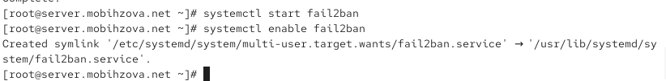

Рисунок 1: Запуск и активация службы Fail2ban.

## Выполнение лабораторной работы

Для мониторинга работы Fail2ban выполнен просмотр журнала событий (рис. 2).

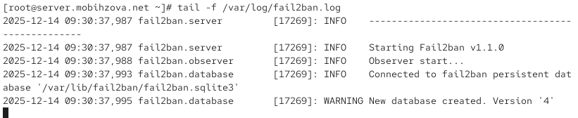

Рисунок 2: Просмотр журнала событий Fail2ban.

## Выполнение лабораторной работы

Создан файл для локальной конфигурации Fail2ban (рис. 3).

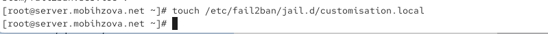

Рисунок 3: Создание файла customisation.local.

## Выполнение лабораторной работы

В файл `customisation.local` добавлены настройки для защиты SSH-службы, включая порт 2022 (рис. 4).

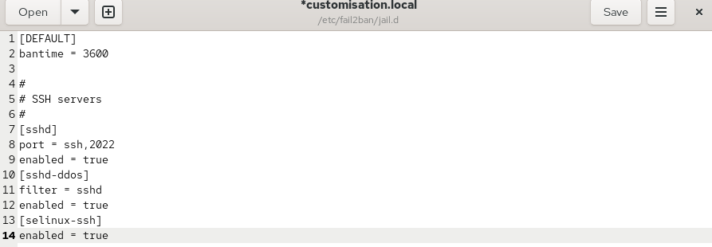

Рисунок 4: Настройка конфигурации SSH в customisation.local.

## Выполнение лабораторной работы

Проверены логи Fail2ban после включения защиты SSH (рис. 6).

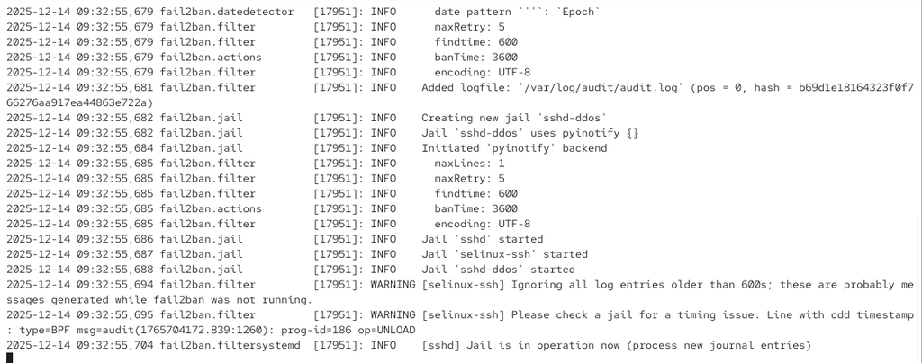

Рисунок 6: Логи Fail2ban после настройки SSH-защиты.

## Выполнение лабораторной работы

В конфигурационный файл добавлены настройки для защиты веб-сервера Apache (рис. 7).

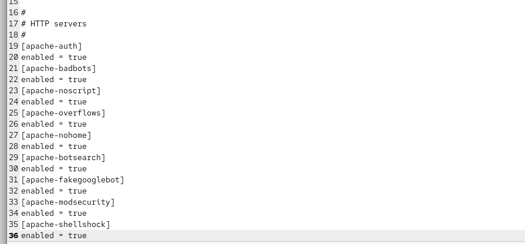

Рисунок 7: Настройка защиты HTTP-служб.

## Выполнение лабораторной работы

Выполнен перезапуск Fail2ban после добавления конфигурации для HTTP (рис. 8).

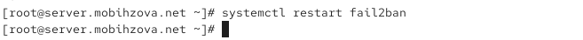

Рисунок 8: Перезапуск Fail2ban после настройки HTTP.

## Выполнение лабораторной работы

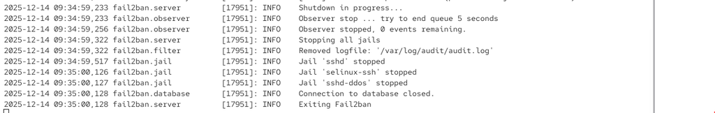

## Выполнение лабораторной работы

Добавлены настройки для защиты почтовых служб (Postfix и Dovecot) (рис. 10).

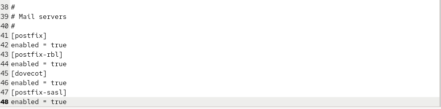

Рисунок 10: Настройка защиты почтовых служб.

## Выполнение лабораторной работы

Выполнен перезапуск Fail2ban после настройки почтовой защиты (рис. 11).

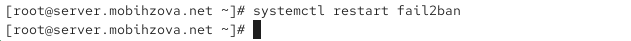

Рисунок 11: Перезапуск Fail2ban после настройки почты.

## Выполнение лабораторной работы

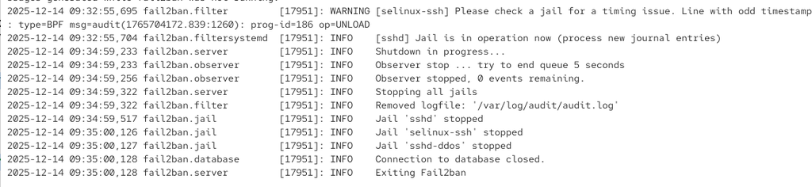

## Выполнение лабораторной работы

Проверен общий статус всех jail в Fail2ban (рис. 13).

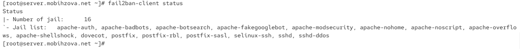

Рисунок 13: Статус всех jail Fail2ban.

## Выполнение лабораторной работы

Проверен статус конкретно SSH-защиты (рис. 14).

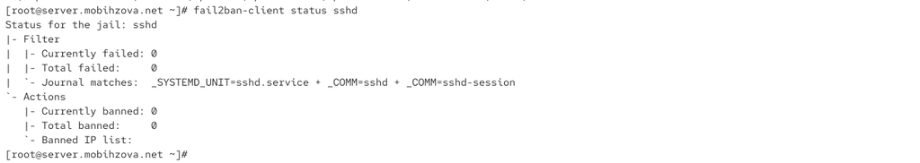

Рисунок 14: Статус SSH-защиты в Fail2ban.

## Выполнение лабораторной работы

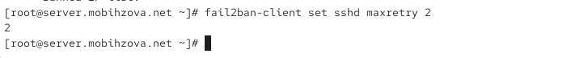

Рисунок 15: Изменение maxretry для SSH.

## Выполнение лабораторной работы

С клиента `client.mobihzova.net` выполнена попытка подключения по SSH с неправильным паролем (рис. 16).

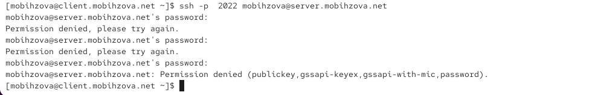

Рисунок 16: Попытка SSH-подключения с неправильным паролем.

## Выполнение лабораторной работы

Проверена блокировка IP-адреса клиента после неудачных попыток (рис. 17).

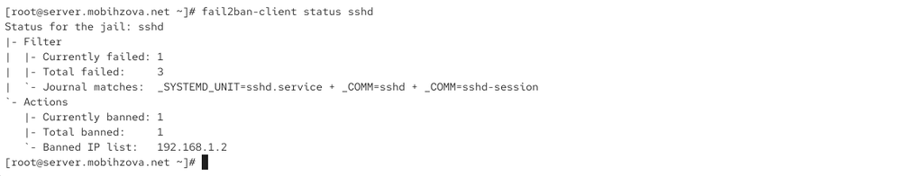

Рисунок 17: Блокировка IP-адреса клиента.

## Выполнение лабораторной работы

Выполнена разблокировка IP-адреса клиента (рис. 18).

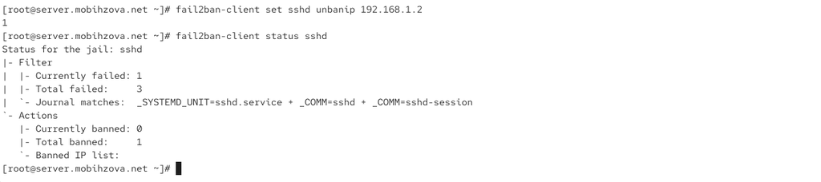

Рисунок 18: Разблокировка IP-адреса.

## Выполнение лабораторной работы

IP-адрес клиента добавлен в список игнорируемых адресов (рис. 19).

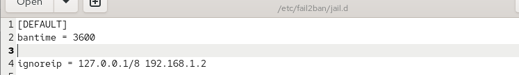

Рисунок 19: Добавление IP-адреса в ignoreip.

## Выполнение лабораторной работы

Выполнен перезапуск Fail2ban после добавления исключений (рис. 20).

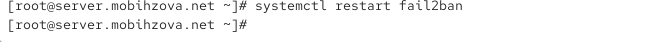

Рисунок 20: Перезапуск Fail2ban с обновлённой конфигурацией.

## Выполнение лабораторной работы

Проверены логи после добавления игнорируемых адресов (рис. 21).

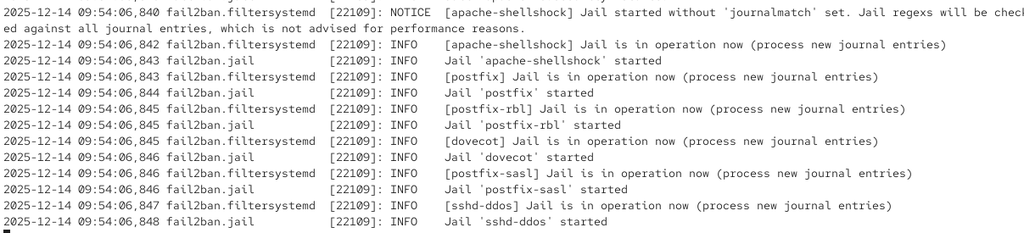

Рисунок 21: Логи Fail2ban с включёнными почтовыми службами.

## Выполнение лабораторной работы

Выполнена повторная попытка SSH-подключения с клиента, IP-адрес которого добавлен в исключения (рис. 22).

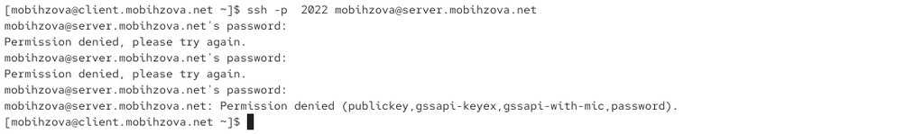

Рисунок 22: Попытка доступа с исключённого IP-адреса.

## Выполнение лабораторной работы

Убедились, что IP-адрес клиента не блокируется после добавления в ignoreip (рис. 23).

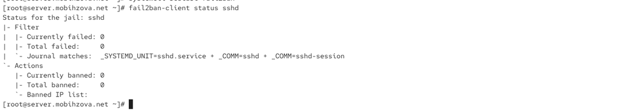

Рисунок 23: Статус SSH-защиты после добавления исключений.

## Выполнение лабораторной работы

Созданы каталоги и скопированы конфигурационные файлы для автоматизации (рис. 24).

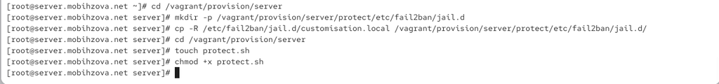

Рисунок 24: Подготовка каталогов для автоматизации.

## Выполнение лабораторной работы

Создан скрипт `protect.sh` для автоматической настройки Fail2ban (рис. 25).

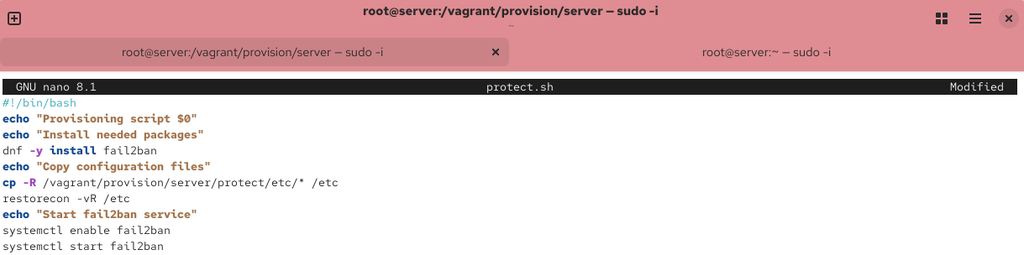

Рисунок 25: Создание скрипта protect.sh.

## Выполнение лабораторной работы

Добавлен вызов скрипта в конфигурацию Vagrantfile (рис. 26).

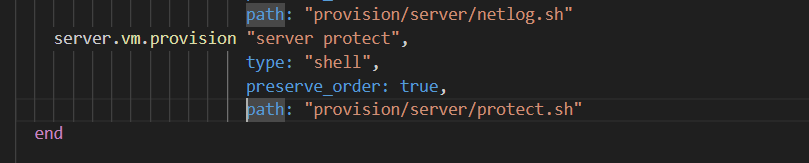

Рисунок 26: Интеграция скрипта в Vagrantfile.

# Выводы

## Выводы

В ходе выполнения лабораторной работы были получены навыки работы с программным средством Fail2ban для обеспечения базовой защиты от атак типа «brute force».